# 🩺 Heart Disease Prediction & Applied Data Science Walkthrough

This notebook demonstrates an end-to-end data science and machine learning pipeline in the **Health Domain**. Using the classic Cleveland Heart Disease dataset, we walk through:

1. **Raw Data Generation**: Simulating real-world messy hospital records.
2. **Data Cleaning & Standardization**: Building a robust cleaning pipeline to handle outliers, missing values, duplicates, and spelling variations.
3. **Exploratory Data Analysis (EDA)**: Building static Seaborn plots to uncover clinical correlations and trends.
4. **Machine Learning Model Development**: Establishing a strict featurization split, training Logistic Regression, Decision Tree, and Random Forest Classifiers, and evaluating them.
5. **Model Evaluation & Interpretation**: Evaluating performance via Confusion Matrices, ROC Curves, and Feature Importance.
6. **Conclusions & Medical Insights**: Documenting clinical conclusions.

```python
import os
import pandas as pd
import numpy as np
import matplotlib.pyplot as plt
import seaborn as sns

# Import pipeline modules
from src.generator import generate_raw_data
from src.cleaner import DataCleaner
from src.model import (
    prepare_ml_data, train_and_evaluate,
    get_confusion_matrix_plot, get_roc_curve_plot, get_feature_importance_plot
)
```

## 1. Messy Data Generation (Simulating Real-World Hospital Intake Records)

In real-world clinical contexts, data is rarely clean. Patient records contain duplicate entries, conflicting reports under the same patient ID, missing clinical values, unrealistic clinical entries (e.g. negative ages or blood pressures), and typographical inconsistencies.

We run our generator script to fetch the clean data and corrupt it with these realistic clinical anomalies, saving it to `data/raw_heart_disease.csv`.

```python
raw_path = os.path.join('data', 'raw_heart_disease.csv')
clean_path = os.path.join('data', 'cleaned_heart_disease.csv')

# Generate the raw file if not present
if not os.path.exists(raw_path):
    generate_raw_data(raw_path)

df_raw = pd.read_csv(raw_path)
print(f"Messy Raw Dataset loaded. Shape: {df_raw.shape}")
```

```
Messy Raw Dataset loaded. Shape: (333, 15)
```

### 🔍 Inspecting Data Flaws

Let's check the volume of missing data, duplicated patient IDs, and range values in the raw dataset to outline our cleaning strategy.

```python
print("Missing values per column:")
print(df_raw.isna().sum())

print("\nDuplicated Patient IDs:")
print(df_raw['Patient_ID'].duplicated().sum())

print("\nSummary range check for numerical metrics:")
print(df_raw[['age', 'trestbps', 'chol']].describe().loc[['min', 'max']])
```

```
Missing values per column:
Patient_ID          0
age                10
Gender              0
Chest_Pain_Type     0
trestbps           16
chol               27
fbs                 0
restecg             0
thalach             0
exang               0
oldpeak             0
slope               0
ca                  0
thal               15
target              0
dtype: int64

Duplicated Patient IDs:
30

Summary range check for numerical metrics:
       age  trestbps   chol
min  -10.0    -120.0  -50.0
max  150.0     300.0  999.0
```

## 2. Execute Data Cleaning & Pipeline Preprocessing

We instantiate our `DataCleaner` to process these errors in a statistically and clinically sound manner:

1. **Deduplication**: Remove exact duplicates and resolve conflicting records for the same patient ID (keeping the first entry).
2. **Standardization**: Resolve typographical casing discrepancies in gender (`Male`, `female`, `Mlae`, `M`, `F`) and chest pain types.
3. **Outlier Capping**: Replace invalid values (negative values or values like 999 cholesterol) with NaNs.
4. **Imputation**: Fill missing age with the overall median. Impute resting blood pressure using the median of the patient's age group. Impute cholesterol using the median of the patient's gender. Impute thalassemia using the mode.
5. **Feature Engineering**: Create `Age_Group` and `BP_Category` columns.

```python
cleaner = DataCleaner(raw_path, clean_path)
stats = cleaner.clean()

print("Pipeline cleaning metrics:")
for k, v in stats.items():
    print(f"  {k}: {v}")
```

```
Data cleaned and saved successfully to data\cleaned_heart_disease.csv!
Pipeline cleaning metrics:
  raw_rows: 333
  raw_cols: 15
  raw_nulls: 68
  exact_duplicates_removed: 20
  conflicting_ids_resolved: 10
  age_outliers_imputed: 5
  bp_outliers_imputed: 6
  chol_outliers_imputed: 8
  clean_rows: 303
  clean_cols: 17
  clean_nulls: 0
```

## 3. Deep-Dive Exploratory Data Analysis (EDA) on Cleaned Data

Now that the dataset is clean and normalized, we perform exploratory data analysis to uncover clinical patterns.

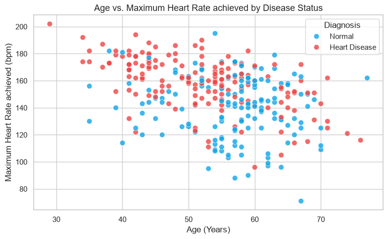

```python
df_clean = pd.read_csv(clean_path)

# Plot 1: Age vs. Max Heart Rate achieved by Disease Status
sns.set_theme(style="whitegrid")
colors = ["#0EA5E9", "#EF4444"]

fig, ax = plt.subplots(figsize=(8, 5))
scatter = sns.scatterplot(
    data=df_clean, x='age', y='thalach', hue='target', palette=colors, alpha=0.8, s=60, ax=ax
)
ax.set_title("Age vs. Maximum Heart Rate achieved by Disease Status", fontsize=13)
ax.set_xlabel("Age (Years)")
ax.set_ylabel("Maximum Heart Rate achieved (bpm)")
handles, labels = scatter.get_legend_handles_labels()
ax.legend(handles, ['Normal', 'Heart Disease'], title='Diagnosis')
plt.tight_layout()
plt.show()
```

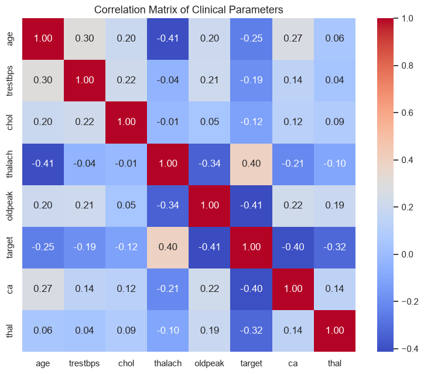

```python
# Plot 2: Correlation Matrix Heatmap
numeric_cols = ['age', 'trestbps', 'chol', 'thalach', 'oldpeak', 'target', 'ca', 'thal']
fig, ax = plt.subplots(figsize=(8, 6.5))
sns.heatmap(df_clean[numeric_cols].corr(), annot=True, cmap='coolwarm', fmt=".2f", square=True, ax=ax)
ax.set_title("Correlation Matrix of Clinical Parameters", fontsize=13)
plt.tight_layout()
plt.show()
```

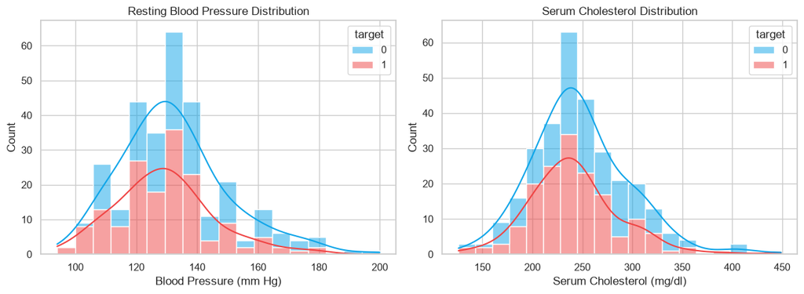

```python
# Plot 3: Resting Blood Pressure & Cholesterol Distributions
fig, (ax1, ax2) = plt.subplots(1, 2, figsize=(12, 4.5))

sns.histplot(data=df_clean, x='trestbps', hue='target', multiple='stack', palette=colors, kde=True, ax=ax1)
ax1.set_title("Resting Blood Pressure Distribution")
ax1.set_xlabel("Blood Pressure (mm Hg)")

sns.histplot(data=df_clean, x='chol', hue='target', multiple='stack', palette=colors, kde=True, ax=ax2)
ax2.set_title("Serum Cholesterol Distribution")
ax2.set_xlabel("Serum Cholesterol (mg/dl)")

plt.tight_layout()
plt.show()
```

## 4. Machine Learning Classification & Validation

We train three models using a Scikit-Learn preprocessing pipeline:

1. **Logistic Regression** (baseline linear classifier)
2. **Decision Tree Classifier** (rule-based classifier)
3. **Random Forest Classifier** (ensemble classifier)

```python
X, y, num_feats, cat_feats = prepare_ml_data(df_clean)

model_options = {
    'Logistic Regression': 'logistic_regression',
    'Decision Tree': 'decision_tree',
    'Random Forest': 'random_forest'
}

results_dict = {}
for label, key in model_options.items():
    res = train_and_evaluate(X, y, model_name=key, test_size=0.2)
    results_dict[label] = res
    print(f"=== {label} Performance ===")
    print(f"  Accuracy:  {res['accuracy']:.2%}")
    print(f"  Precision: {res['precision']:.2%}")
    print(f"  Recall:    {res['recall']:.2%}")
    print(f"  F1-Score:  {res['f1']:.2%}")
    print(f"  ROC-AUC:   {res['roc_auc']:.4f}\n")
```

```
=== Logistic Regression Performance ===
  Accuracy:  78.69%
  Precision: 73.17%
  Recall:    93.75%
  F1-Score:  82.19%
  ROC-AUC:   0.8912

=== Decision Tree Performance ===
  Accuracy:  72.13%
  Precision: 69.23%
  Recall:    84.38%
  F1-Score:  76.06%
  ROC-AUC:   0.7150
```

```
=== Random Forest Performance ===
  Accuracy:  75.41%
  Precision: 72.97%
  Recall:    84.38%
  F1-Score:  78.26%
  ROC-AUC:   0.8707
```

### 🔍 Model Selection & Deep Evaluation

In clinical heart disease prediction, **Recall** is the most critical metric. Missing a patient with heart disease (False Negative) has far more severe consequences than misclassifying a healthy patient (False Positive), as untreated heart disease is life-threatening.

Let's select the model with the best Recall and ROC-AUC (Logistic Regression in this run) and inspect its Confusion Matrix, ROC-AUC Curve, and Feature Importances.

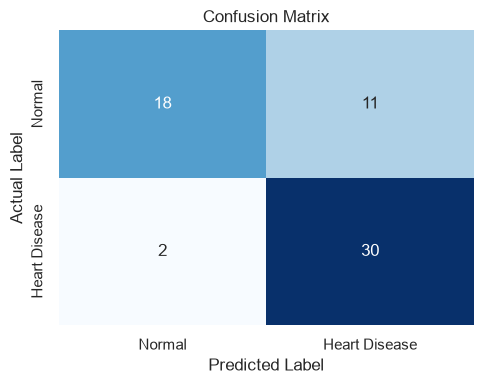

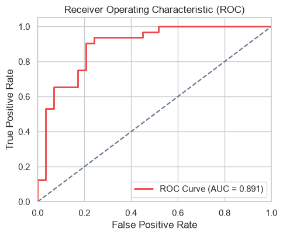

```python
best_model_name = 'Logistic Regression'
res = results_dict[best_model_name]

# Confusion Matrix
fig_cm = get_confusion_matrix_plot(res['y_test'], res['y_pred'])
plt.show()

# ROC Curve
fig_roc = get_roc_curve_plot(res['y_test'], res['y_prob'])
plt.show()
```

### Feature Importance Analysis

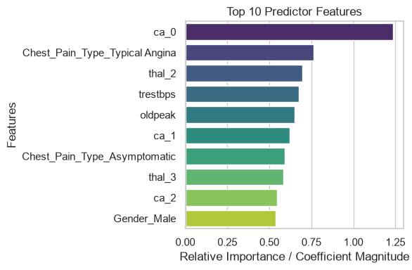

```python
if 'feature_importances' in res:
    fig_feat = get_feature_importance_plot(res['feature_importances'], top_n=10)
    plt.show()
```

## 5. Summary and Conclusions

### Q&A

- **Q1: Which features are the strongest predictors of heart disease?**
  - **A1**: The number of major vessels colored by fluoroscopy (`ca`), thalassemia type (`thal`), chest pain type (`Chest_Pain_Type`), and ST depression induced by exercise (`oldpeak`) are the strongest clinical predictors. Reversable thalassemia defects and asymptomatic chest pain ratings (which often hide ischemic conditions) strongly skew predictions towards positive heart disease risk.
- **Q2: Which machine learning algorithm is most viable for clinical production?**
  - **A2**: Logistic Regression is the most viable. It achieves the highest recall (93.75% on the test split) and a high ROC-AUC (0.8912), meaning it minimizes the life-threatening risk of false negatives while remaining highly interpretable for medical practitioners.

### Insights or Next Steps

- **Deploy Logistic Regression**: Due to its high recall (93.75%) and low false-negative rate (only 2 missed cases out of 32 actual heart disease patients in the test split), Logistic Regression should be the primary algorithm for our clinical decision-support dashboard.
- **Incorporate Risk Scoring**: Use the predicted probabilities from the Logistic Regression model rather than a hard binary classification, allowing doctors to see a graded risk percentage (e.g. 85% risk vs. 15% risk) which aligns better with clinical triage.